# Comparativa de simulaciones de SIMANFOR

Aitor Vázquez Veloso

2025-03-08

## Introducción

En este archivo se presentan los pasos básicos para el análisis de resultados de simulaciones en SIMANFOR.

Este código necesita la intervención del usuario para definir algunas variables antes de ejecutarlo. Por otro lado, los archivos resultantes de las simulaciones de SIMANFOR deben:

- estar descomprimidos
- estar dentro de una carpeta principal que englobe todos los resultados
- cada grupo de simulaciones debe estar en una carpeta separada dentro de la carpeta principal

*Nota: los grupos de simulaciones se refieren a los casos que queremos comparar con este análisis.* *Por lo general compararemos distintos escenarios de gestión forestal, pero también podríamos comparar parcelas con* *distintas densidades iniciales, calidades de estación, zonas de estudio, proporción de especies… simuladas bajo un* *mismo escenario de gestión. En la imagen de a continuación podemos ver (1) un caso de estudio donde se ha aplicado la* *misma gestión a masas con distinta productividad, y (2) un caso de estudio donde se ha aplicado distinta gestión.* *Puedes encontrar estos archivos en el repositorio de [resultados de SIMANFOR](https://github.com/simanfor/resultados)*

*Por cierto, en estas carpetas puedes poner un nombre que represente el grupo de simulaciones que contiene, como por* *ejemplo una gestión forestal concreta, una especie de interés, una zona de estudio, etc.* *Este nombre será el que se muestre en la leyenda de los gráficos, por lo que es importante que sea descriptivo y corto.*

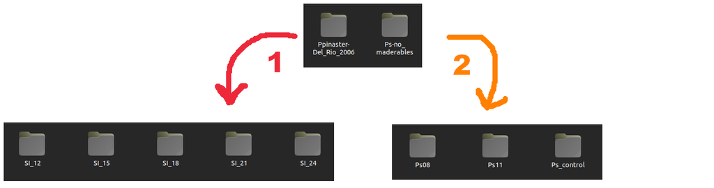

Figura 1. Estructura de ejemplo para las carpetas con resultados

## Instalación y carga de paquetes

Para que este código funcione correctamente, es necesario mantener el archivo `functions.r` en la misma carpeta que este archivo. Este archivo contiene funciones necesarias para la ejecución de este código.

```r
source('functions.r')
install_and_load(c("readxl", "tidyverse", "ggplot2", "viridis"))
# install_and_load(c("tinytex", "rmarkdown", "knitr"))  # estas librerías son necesarias para la creación de informes
```

Sería necesario establecer nuestro directorio de trabajo, pero con los archivos *.Rmd* no es necesario, ya que toman como directorio de trabajo la carpeta donde se encuentran.

## Configuración inicial de variables

Ahora es tu turno. Configura las siguientes variables para que el código funcione correctamente. Comencemos con la ruta de los archivos de simulación. Sustituye la ruta que aparece a continuación por la ruta de la carpeta principal donde se encuentran tus archivos (recuerda, esta debe tener subcarpetas con los resultados de cada grupo de simulaciones). El código se mostrará los archivos que se encuentran en esa carpeta.

*Nota: si estás trabajando en Windows, recuerda cambiar la orientación de las barras a esta:* */*

```r
simulations_path <- '/home/aitor/Downloads/Ps-no_maderables'
list.files(simulations_path, full.names = TRUE)
```

```
## [1] "/home/aitor/Downloads/Ps-no_maderables/Ps_control"
## [2] "/home/aitor/Downloads/Ps-no_maderables/Ps08"
## [3] "/home/aitor/Downloads/Ps-no_maderables/Ps11"
## [4] "/home/aitor/Downloads/Ps-no_maderables/README.md"
```

Continuemos configurando las siguientes variables:

- *lang* = **Idioma de los resultados obtenidos de SIMANFOR:** `es` (Español) o `en` (Inglés)
- *projection_time* = **Tiempo de proyección del modelo:** Ver [documentación del modelo](https://github.com/simanfor/modelos) o consultar dato en la [página web de SIMANFOR](https://www.simanfor.es/models)
- *save* = **Quieres guardar los gráficos que vas a crear?** `si` o `no`
- *output_path* = **Ruta de salida de gráficos:** Carpeta donde se guardarán los gráficos generados (por defecto es la carpeta de trabajo)

```r
lang <- "es"
projection_time <- 5
save <- "si"
output_path <- getwd()
```

### Carga de resultados

El siguiente paso es cargar los datos de las simulaciones. Para ello, usaremos la función `load_plot_data` que se encuentra en el archivo `functions.r`. Tus datos se cargarán en un data frame llamado `plots`. Una vez cargados, podremos graficar los resultados, pero antes, sería interesante echar un vistazo a los datos para conocer qué variables tenemos disponibles para graficar y qué valores toman. Recuerda que en los archivos de resultados de SIMANFOR tienes una hoja llamada “Metadatos” donde puedes consultar el significado de cada variable y las unidades en las que se expresan. Te dejo por aquí una serie de comandos que puedes utilizar para explorar tus datos:

- **dim(plots)**: Número de filas y columnas
- **str(plots)**: Estructura de los datos (tipos de variables)
- **glimpse(plots)**: Similar a str(), pero más compacto
- **names(plots)**: Nombres de las variables
- **head(plots, 10)**: Primeras 10 filas del dataframe
- **tail(plots, 10)**: Últimas 10 filas
- **summary(plots)**: Estadísticas descriptivas generales

```r
plots <- load_plot_data(simulations_path, lang)
```

Los gráficos suelen crearse utilizando la edad del rodal para observar su evolución y los efectos de la silvicultura. Verificar la edad inicial del rodal en nuestras parcelas es una buena práctica, especialmente cuando el inventario incluye diferentes edades iniciales. En nuestro ejemplo, se ve así:

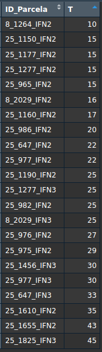

edades_parcelas

Las edades iniciales de las parcelas varían entre 10 y 45 años. Las parcelas que siguen la misma selvicultura se promediarán, y las diferencias en la edad inicial del rodal pueden afectar los gráficos, como veremos más adelante. Siéntete libre de explorar todas las variables disponibles para comprender mejor tus datos.

### Creación de gráficos

Genial, ya hemos dado los pasos necesarios para comenzar a graficar los resultados de las simulaciones. Para ello vamos a utilizar la función `graph_selector` que se encuentra en el archivo `functions.r`. Esta función nos permitirá seleccionar el tipo de gráfico que queremos crear y personalizarlo según nuestras necesidades. Para ello, debemos definir los siguientes argumentos:

- **df:** Data frame con los resultados (por defecto, `plots`)
- **projection_time:** Tiempo de proyección del modelo usado en las simulaciones (lo hemos definido anteriormente)
- **lang:** Idioma de los resultados (lo hemos definido anteriormente)
- **save:** Guardar los gráficos (lo hemos definido anteriormente)
- **output_path:** Ruta donde se guardarán los gráficos (lo hemos definido anteriormente)
- **graph_type:** Devuelve un gráfico donde se muestra la evolución de la variable seleccionada a lo largo de la simulación para:
  - `"en pie"`: masa que permanece en pie y no es extraída mediante cortas
  - `"acumulado"`: la suma de la masa en pie y la masa extraída mediante cortas
  - `"en pie + acumulado"`: ambos resultados en un mismo gráfico
- **x_axis_var:** Variable a representar en el eje X, a elegir entre: `T` (edad de la masa), `Anho` (año para el que se han hecho las predicciones), o `Edad_de_escenario` (tiempo simulado, teniendo tu inventario inicial el valor 0). *Nota: revisa tus datos para saber qué variables tienes disponibles (por defecto se utiliza `T`). Ten en cuenta que* *los resultados serán diferentes dependiendo de los valores iniciales de estas variables en cada parcela utilizada,* *puesto que se calculará el valor promedio de todas ellas*
- **y_axis_var:** Variable numérica a graficar en el eje Y
- **title:** Título del gráfico (no lo incluyas si no quieres título)
- **subtitle:** Subtítulo del gráfico (no lo incluyas si no quieres subtítulo)
- **x:** Etiqueta del eje X (no lo incluyas si no quieres etiqueta)
- **y:** Etiqueta del eje Y (no lo incluyas si no quieres etiqueta)

*Nota: los gráficos guardados en tu ordenador están reescalados para evitar cortes en el texto y mejorar la presentación*

#### Ejemplo de gráficos: valores en pie

##### Evolución de la densidad del rodal

Ten en cuenta que las variaciones extremas por debajo de los 50 años se deben a las diferencias en la edad inicial del rodal en las parcelas utilizadas, como mencionamos anteriormente. Los valores se promedian según la edad del rodal, por lo que, si una parcela más madura con una densidad mayor que la anterior entra en la simulación, la densidad media aumentará. Por el contrario, si ingresa una nueva parcela con una densidad menor que la anterior, la densidad media disminuirá. Una vez que todas las parcelas están incluidas en la simulación, la evolución del rodal se vuelve más estable y fácil de evaluar.

*Nota: En todos los gráficos, cada grupo de parcelas (en este caso, cada escenario selvícola) se representará con un*  
*color diferente. Cada acción propuesta en nuestro escenario (inicialización, proyección o cosecha) se marcará en el*  
*gráfico con un símbolo distinto. Consulta la leyenda para más detalles.*

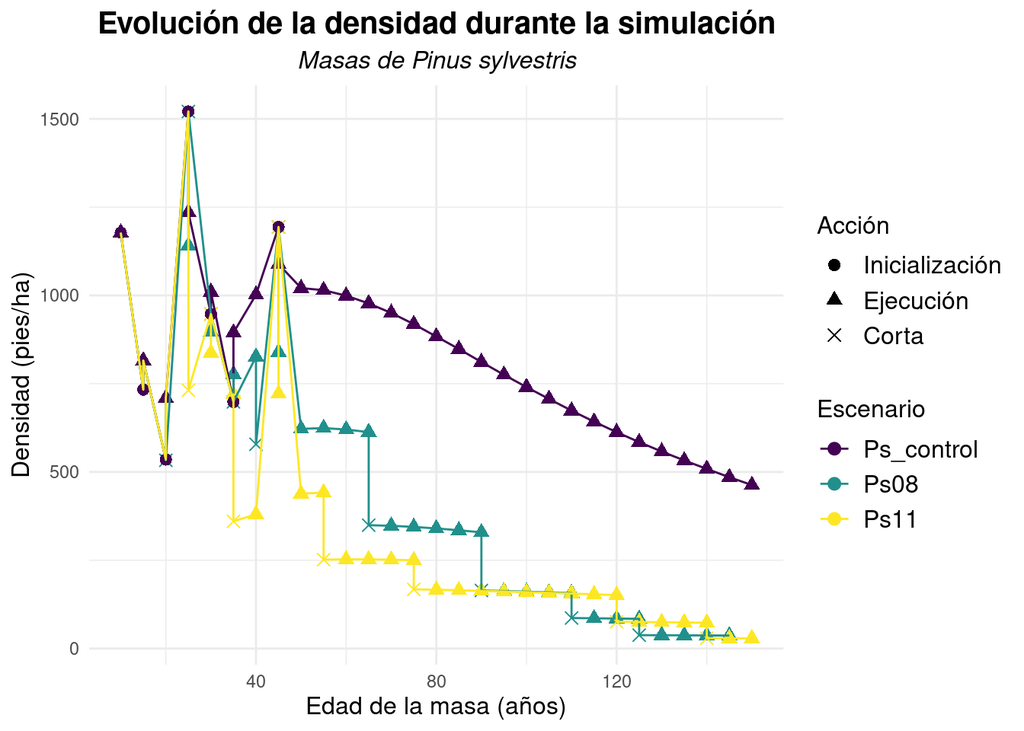

```r
graph_selector(df = plots, projection_time = projection_time, lang = lang,
               save = save, output_path = output_path,
               graph_type = "en pie", x_axis_var = "T", y_axis_var = "N",
               title = "Evolución de la densidad durante la simulación",
               subtitle = "Masas de Pinus sylvestris",
               x = "Edad de la masa (años)", y = "Densidad (pies/ha)")
```

##### Evolución de la altura dominante

Para mostrarte cómo modificar los argumentos restantes, esta vez estableceré el argumento *save* para evitar guardar el gráfico y eliminaré el argumento *output_path*, ya que no será necesario.

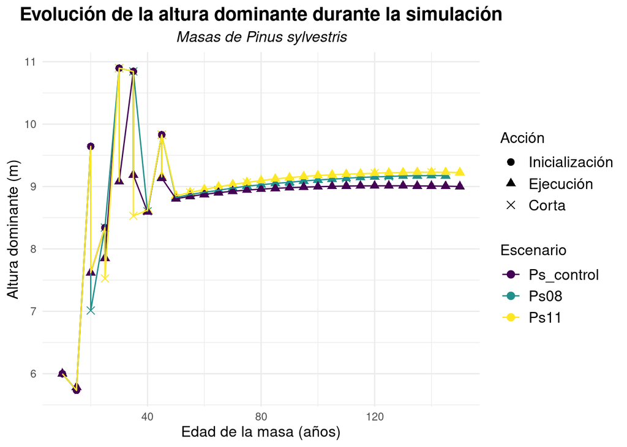

```r
graph_selector(df = plots, projection_time = projection_time, lang = lang,
               # save = save, output_path = output_path,
               save = 'no',
               graph_type = "en pie", x_axis_var = "T", y_axis_var = "Ho",
               title = "Evolución de la altura dominante durante la simulación",
               subtitle = "Masas de Pinus sylvestris",
               x = "Edad de la masa (años)", y = "Altura dominante (m)")
```

#### Ejemplo de gráfico: valores acumulados

##### Evolución de la biomasa acumulada, incluyendo todas las secciones del árbol (raíces, tronco, copa)

Este gráfico puede tardar un poco más en generarse. Por favor, espera, todo está funcionando correctamente.

En este gráfico puedes observar que ambos escenarios selvícolas logran una mayor producción de biomasa al final de la simulación. Además, el símbolo **x** (que indica una corta) se encuentra en la misma posición que el símbolo de proyección, lo que significa que se realizó una corta, pero la biomasa extraída no fue descontada. Estos gráficos muestran la producción total de biomasa, incluyendo la biomasa extraída en las cortas, para comparar la productividad general en lugar de solo la biomasa que permanece en el rodal.

*Nota: Tiene sentido usar este tipo de gráfico para variables como el volumen o la biomasa, mientras que la densidad* *del rodal o la altura dominante no son adecuadas para este tipo de análisis.*

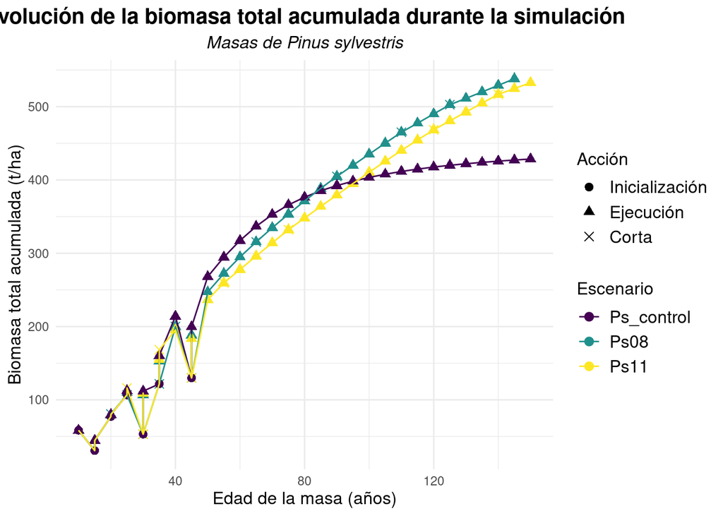

```r
graph_selector(df = plots, projection_time = projection_time, lang = lang,
               save = save, output_path = output_path,
               graph_type = "acumulado", x_axis_var = "T", y_axis_var = "WT",
               title = "Evolución de la biomasa total acumulada durante la simulación",
               subtitle = "Masas de Pinus sylvestris",
               x = "Edad de la masa (años)", y = "Biomasa total acumulada (t/ha)")
```

##### Evolución de la biomasa acumulada del tronco, excluyendo las demás secciones del árbol (raíces, ramas y copa)

Para mostrarte cómo modificar los argumentos restantes, esta vez omitiré las etiquetas de ambos ejes.

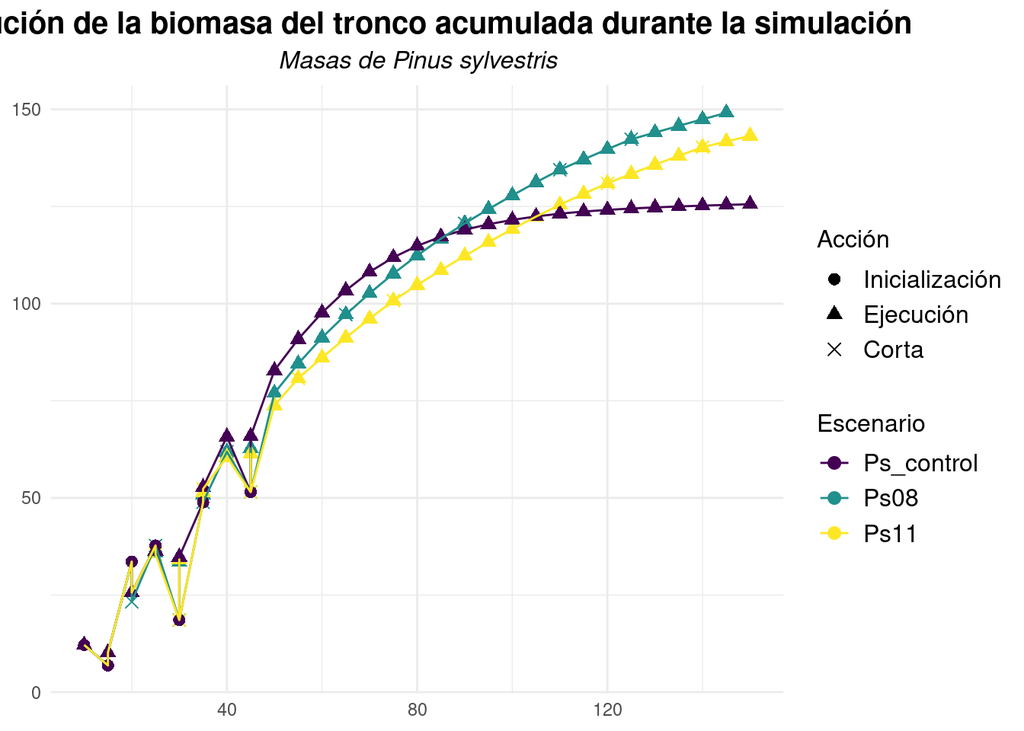

```r
graph_selector(df = plots, projection_time = projection_time, lang = lang,
               save = save, output_path = output_path,
               graph_type = "acumulado", x_axis_var = "T", y_axis_var = "WSW",
               title = "Evolución de la biomasa del tronco acumulada durante la simulación",
               subtitle = "Masas de Pinus sylvestris"#,
               #x = "Edad de la masa (años)", y = "Biomasa acumulada del tronco (t/ha)"
               )
```

#### Ejemplo de gráfico: valores en pie + acumulados

##### Evolución del volumen con corteza (en pie + acumulado)

En este tipo de gráfico, puedes comparar directamente la producción total acumulada durante la simulación con la producción que permanece en el monte en los árboles vivos al final de la simulación (en pie). Además, permite la comparación simultánea de todos los escenarios selvícolas.

*Nota: La línea sólida representa la producción total (en pie + extraída); la línea discontinua representa el valor en pie.*

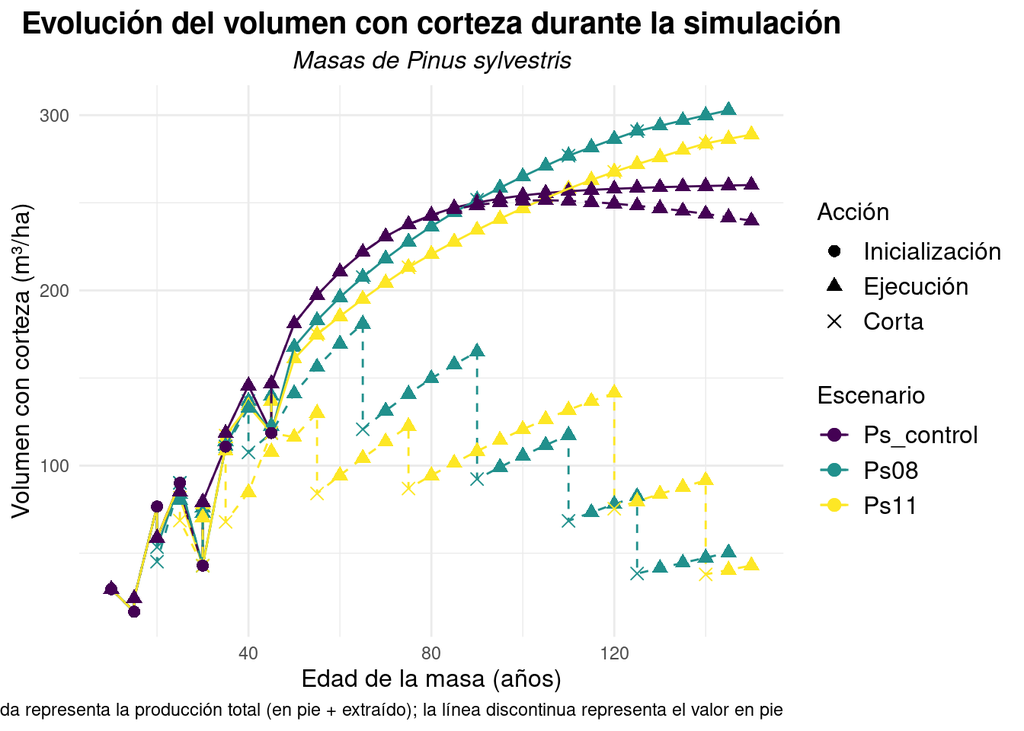

```r
graph_selector(df = plots, projection_time = projection_time, lang = lang,
               save = save, output_path = output_path,
               graph_type = "en pie + acumulado", x_axis_var = "T", y_axis_var = "V_con_corteza",
               title = "Evolución del volumen con corteza durante la simulación",
               subtitle = "Masas de Pinus sylvestris",
               x = "Edad de la masa (años)", y = "Volumen con corteza (m³/ha)")
```

##### Evolución del volumen con corteza (en pie + acumulado) - *Eje X = Año*

Para mostrarte cómo modificar los argumentos restantes, esta vez omitiré el título y el subtítulo. Además, cambiaré la variable del eje X a `Anho` para mostrarte cómo cambia el gráfico.

¿Qué está ocurriendo en nuestro gráfico? Bueno, es un desastre… Como recordarás, en este ejemplo estamos trabajando con múltiples parcelas que tienen diferentes condiciones iniciales. Por esta razón, el gráfico parece tan caótico. Los valores promedio se calculan en función de la edad del rodal, pero el eje X muestra la variable *Year* en lugar de la edad del rodal. Esta discrepancia provoca un desalineamiento en el eje X, lo que dificulta la interpretación del gráfico (y lo vuelve poco interesante).

Recomiendo usar la edad del rodal como variable del eje X al trabajar con este tipo de gráfico. Sin embargo, si tus parcelas tienen las mismas condiciones iniciales, puedes usar las variables *Anho* o *Edad_de_escenario* sin problemas.

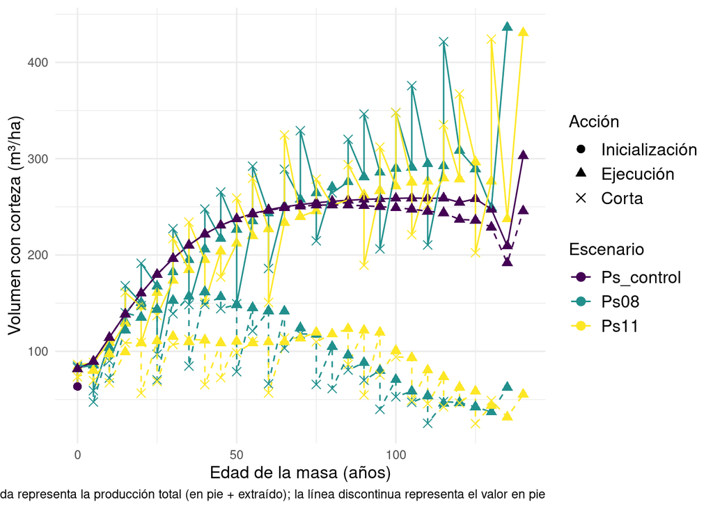

```r
graph_selector(df = plots, projection_time = projection_time, lang = lang,
               save = save, output_path = output_path,
               graph_type = "en pie + acumulado", x_axis_var = "Anho", y_axis_var = "V_con_corteza",
               # title = "Evolución del volumen con corteza durante la simulación",
               # subtitle = "Masas de Pinus sylvestris",
               x = "Edad de la masa (años)", y = "Volumen con corteza (m³/ha)")
```

### Resumen de datos: biomasa total

Además de visualizar nuestros resultados mediante gráficos, es muy útil generar una tabla resumen que nos permita observar cómo evoluciona la variable de interés a lo largo del tiempo. En este caso, queremos analizar la evolución de la masa, los valores acumulados y los valores extraídos durante la simulación. Para ello, utilizamos la función `get_variable_summary`, incluida en el archivo `functions.r`.

Esta función permite resumir cualquier variable numérica del conjunto de datos, agrupándola en función de una variable temporal. Los argumentos que acepta son los siguientes:

- **df:** Data frame con los resultados (por defecto, `plots`)
- **x_axis_var:** Variable temporal para agrupar los valores de la variable *y*, a elegir entre: `T` (edad de la masa), `Anho` (año para el que se han hecho las predicciones), o `Edad_de_escenario` (tiempo simulado, teniendo tu inventario inicial el valor 0). *Nota: revisa tus datos para saber qué variables tienes disponibles (por defecto se utiliza `T`). Ten en cuenta que* *los resultados serán diferentes dependiendo de los valores iniciales de estas variables en cada parcela utilizada,* *puesto que se calculará el valor promedio de todas ellas*
- **y_axis_var:** Variable numérica sobre la que se quieren hacer los cálculos
- **projection_time:** Tiempo de proyección del modelo usado en las simulaciones (lo hemos definido anteriormente)
- **lang:** Idioma de los resultados (lo hemos definido anteriormente)
- **save:** Guardar los datos (lo hemos definido anteriormente)
- **output_path:** Ruta donde se guardarán los datos (lo hemos definido anteriormente)

```r
df_wt <- get_variable_summary(df = plots, x_axis_var = "T", y_axis_var = "WT", projection_time = 5,
                              lang = "es", save = "yes", output_path = output_path)
```

Una vez creada la tabla resumen, podemos examinar su contenido con funciones básicas:

```r
head(df_wt)
```

```
## # A tibble: 6 × 6
## # Groups:   folder_name [1]
##   folder_name T_grouped Accion         WT_original WT_acumulado WT_extraido
##   <chr>           <dbl> <chr>                <dbl>        <dbl>       <dbl>
## 1 Ps08               10 Inicialización        58.4         58.4         0
## 2 Ps08               10 Ejecución             58.4         58.4         0
## 3 Ps08               15 Inicialización        30.7         30.7        27.7
## 4 Ps08               15 Ejecución             38.2         38.2        27.7
## 5 Ps08               20 Inicialización        77.3         77.3        27.7
## 6 Ps08               20 Ejecución             79.4         79.4        27.7
```

```r
summary(df_wt)
```

```
##  folder_name          T_grouped         Accion           WT_original
##  Length:125         Min.   : 10.00   Length:125         Min.   : 30.75
##  Class :character   1st Qu.: 30.00   Class :character   1st Qu.: 96.76
##  Mode  :character   Median : 60.00   Mode  :character   Median :148.43
##                     Mean   : 67.68                      Mean   :176.89
##                     3rd Qu.:105.00                      3rd Qu.:220.01
##                     Max.   :150.00                      Max.   :422.10
##   WT_acumulado     WT_extraido
##  Min.   : 30.75   Min.   :  0.00
##  1st Qu.:109.69   1st Qu.: 86.07
##  Median :294.68   Median :170.23
##  Mean   :270.62   Mean   :221.35
##  3rd Qu.:417.61   3rd Qu.:306.75
##  Max.   :538.15   Max.   :642.11
```

### Resumen de datos: variables nuevas

Además de trabajar con variables ya presentes en nuestros resultados, también podemos crear nuevas variables combinando otras existentes. Por ejemplo, podemos calcular la biomasa aérea (WSB), que incluye la biomasa del tronco y de las ramas, sumando las siguientes variables:

- **WSW**: biomasa del tronco
- **WTHICKB, WB2_7, WTBL**: biomasa de ramas de diferentes tamaños

El cálculo de esta nueva variable y su posterior resumen sería:

```r
plots$WSB <- plots$WSW + plots$WTHICKB + plots$WB2_7 + plots$WTBL  # cálculo de la biomasa aérea (t/ha)
df_wsb <- get_variable_summary(df = plots, x_axis_var = "T", y_axis_var = "WSB", projection_time = 5,
                                    lang = "es", save = "no")
```

# Ejemplo 2: Comparación entre distinas Calidades de Estación

¡Genial! Ahora repetiré el proceso utilizando otro conjunto de simulaciones.  
Esta vez, compararé la evolución de un rodal similar ubicado en diferentes áreas de Calidad de Estación bajo un escenario selvícola común.

Esta vez omitiré las explicaciones, ya que el proceso es el mismo que en el caso anterior.  
Solo te mostraré el código y los gráficos resultantes.

```r
rm(list = ls())
source('functions.r')
simulations_path <- '/home/aitor/Downloads/Ppinaster-Del_Rio_2006/'
list.files(simulations_path, full.names = TRUE)
```

```
## [1] "/home/aitor/Downloads/Ppinaster-Del_Rio_2006//SI_12"
## [2] "/home/aitor/Downloads/Ppinaster-Del_Rio_2006//SI_15"
## [3] "/home/aitor/Downloads/Ppinaster-Del_Rio_2006//SI_18"
## [4] "/home/aitor/Downloads/Ppinaster-Del_Rio_2006//SI_21"
## [5] "/home/aitor/Downloads/Ppinaster-Del_Rio_2006//SI_24"
```

```r
lang <- "es"
projection_time <- 5
save <- "no"
# output_path <- getwd()
plots <- load_plot_data(simulations_path, lang)
```

#### Ejemplo de gráficos: valores en pie

##### Evolución de la densidad del rodal

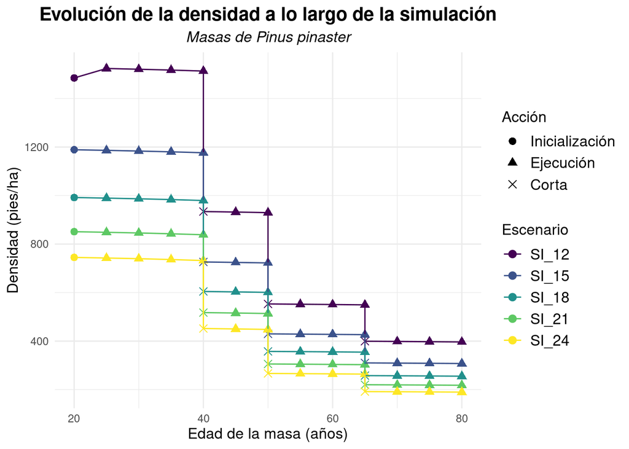

```r
graph_selector(df = plots, projection_time = projection_time, lang = lang,
               save = save,
               graph_type = "en pie", x_axis_var = "T", y_axis_var = "N",
               title = "Evolución de la densidad a lo largo de la simulación",
               subtitle = "Masas de Pinus pinaster",
               x = "Edad de la masa (años)", y = "Densidad (pies/ha)")
```

##### Evolución del área basimétrica del rodal

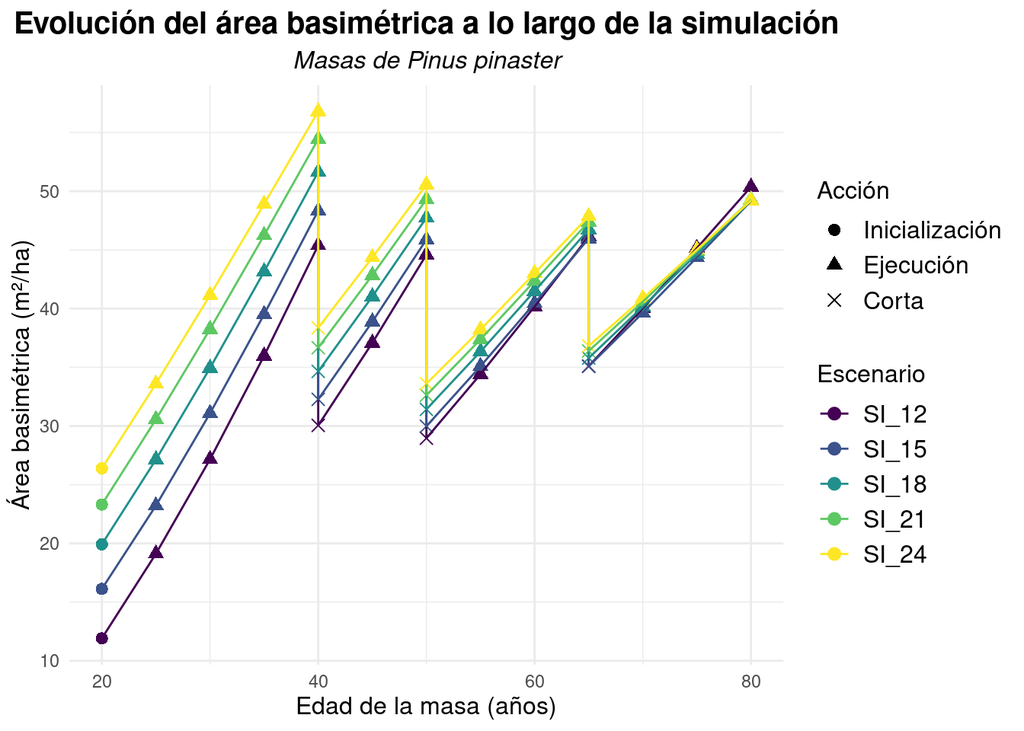

```r
graph_selector(df = plots, projection_time = projection_time, lang = lang,
               save = save,
               graph_type = "en pie", x_axis_var = "T", y_axis_var = "G",
               title = "Evolución del área basimétrica a lo largo de la simulación",
               subtitle = "Masas de Pinus pinaster",
               x = "Edad de la masa (años)", y = "Área basimétrica (m²/ha)")
```

##### Evolución de la altura dominante del rodal

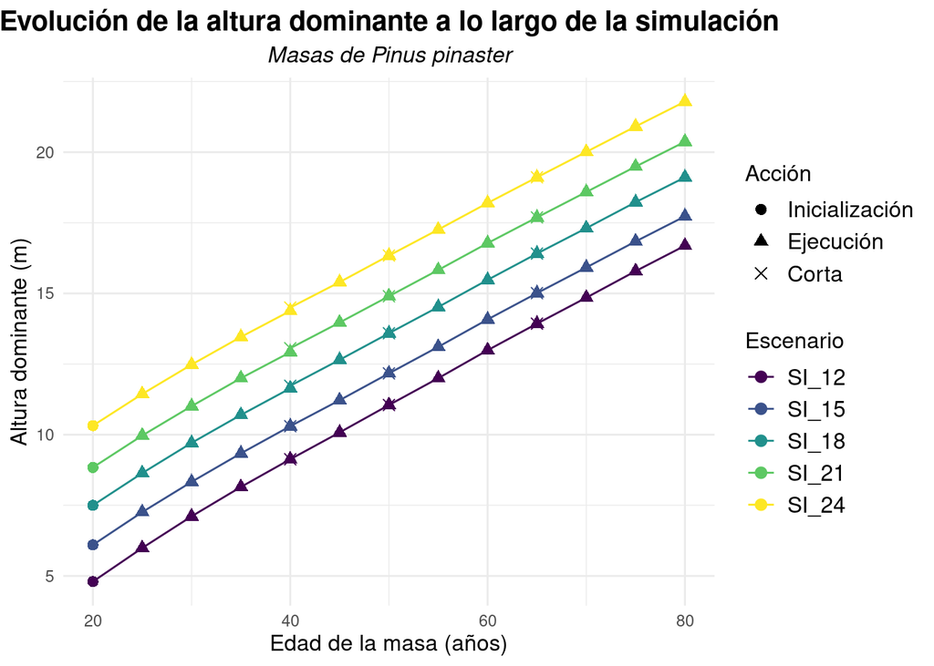

```r
graph_selector(df = plots, projection_time = projection_time, lang = lang,
               save = save,
               graph_type = "en pie", x_axis_var = "T", y_axis_var = "Ho",
               title = "Evolución de la altura dominante a lo largo de la simulación",
               subtitle = "Masas de Pinus pinaster",
               x = "Edad de la masa (años)", y = "Altura dominante (m)")
```

#### Ejemplo de gráfico: valores acumulados - *Eje X = Año*

##### Evolución de la biomasa acumulada del tronco

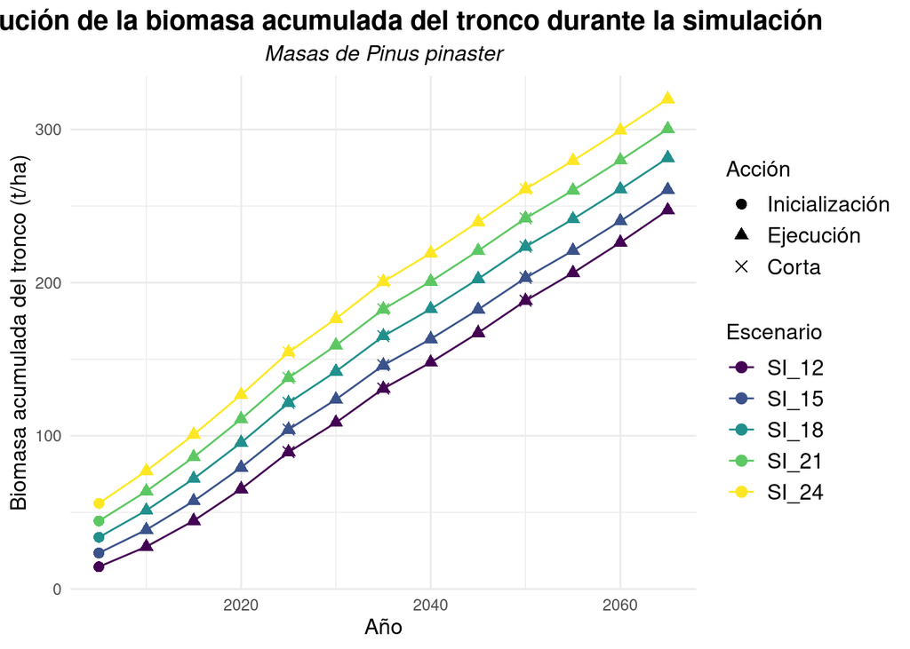

```r
graph_selector(df = plots, projection_time = projection_time, lang = lang,
               save = save,
               graph_type = "acumulado", x_axis_var = "Anho", y_axis_var = "WSW",
               title = "Evolución de la biomasa acumulada del tronco durante la simulación",
               subtitle = "Masas de Pinus pinaster",
               x = "Año", y = "Biomasa acumulada del tronco (t/ha)")
```

##### Evolución del volumen sin corteza

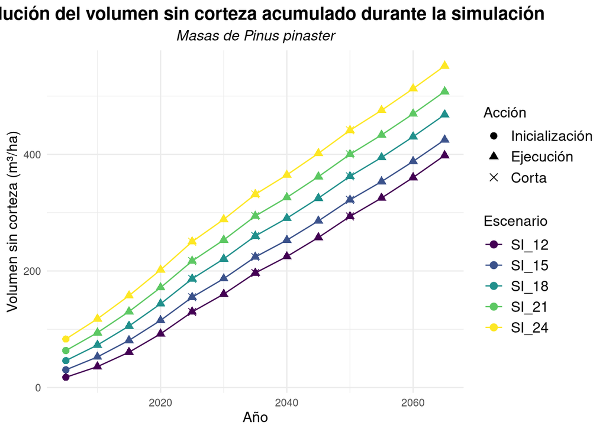

```r
graph_selector(df = plots, projection_time = projection_time, lang = lang,
               save = save,
               graph_type = "acumulado", x_axis_var = "Anho", y_axis_var = "V_sin_corteza",
               title = "Evolución del volumen sin corteza acumulado durante la simulación",
               subtitle = "Masas de Pinus pinaster",
               x = "Año", y = "Volumen sin corteza (m³/ha)")
```

#### Ejemplo de gráfico: valores en pie + acumulados - *Eje X = Edad_de_escenario*

##### Evolución de la biomasa del tronco en pie + acumulada

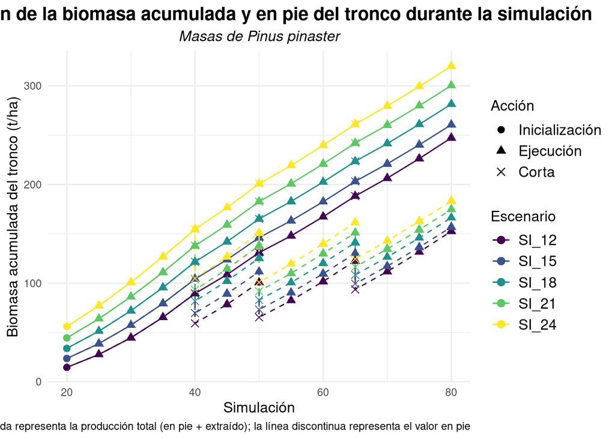

```r
graph_selector(df = plots, projection_time = projection_time, lang = lang,
               save = save,
               graph_type = "en pie + acumulado", x_axis_var = "Edad_de_escenario", y_axis_var = "WSW",
               title = "Evolución de la biomasa acumulada y en pie del tronco durante la simulación",
               subtitle = "Masas de Pinus pinaster",
               x = "Simulación", y = "Biomasa acumulada del tronco (t/ha)")
```

##### Evolución del volumen sin corteza en pie + acumulado

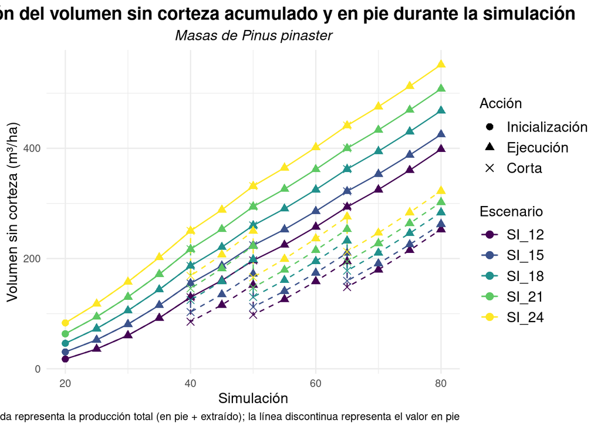

```r
graph_selector(df = plots, projection_time = projection_time, lang = lang,
               save = save,
               graph_type = "en pie + acumulado", x_axis_var = "Edad_de_escenario", y_axis_var = "V_sin_corteza",
               title = "Evolución del volumen sin corteza acumulado y en pie durante la simulación",
               subtitle = "Masas de Pinus pinaster",
               x = "Simulación", y = "Volumen sin corteza (m³/ha)")
```